# Kaggle 데이터를 활용한 RSI 지표 예측

## 4. 예측 결과

- RSI >= 0.7이면 과매수 신호
- RSI <= 0.3이면 과매도 신호
- Testset에서 실제 RSI와 예측 RSI를 활용한 매수 매도 포지션이 일치하는지 확인한 결과, 82% 일치함.
- 다만, 실제 투자에서는 단순히 0.3이하, 0.7이상일 때 매수 매도를 진행하지 않으며 다른 지표들도 함께 고려해야 함.
- 과매수 및 과매도 신호를 확인할 수 있다는 점에서 의의가 있음.
- 더 나아가, 예측값을 활용하여 투자를 진행했을 때의 수익률과 실제 수익률을 비교하여 얼마나 값이 차이가 나는지 비교할 수도 있을 것.

```python
# 예측 결과 테이블 생성
testset = pd.DataFrame(y_test).reset_index()
testset.drop('index', axis=1, inplace=True)
predicted_y = pd.DataFrame({'predicted':y_pred})
predicted_table = pd.concat([testset,predicted_y], axis=1)
predicted_table.info()
```

```
<class 'pandas.core.frame.DataFrame'>
RangeIndex: 596 entries, 0 to 595
Data columns (total 2 columns):
 #   Column     Non-Null Count  Dtype
---  ------     --------------  -----
 0   rsi        596 non-null    float64
 1   predicted  596 non-null    float64
dtypes: float64(2)
memory usage: 9.4 KB
```

[figure not shown]

[figure not shown]

```python
sns.set(font_scale = 1)
plt.figure(figsize = (8,10))
plt.subplot(2,1,1)
plt.plot(predicted_table['rsi'], color='r', label='Predicted Close')
plt.title('Predicted RSI')

sns.set(font_scale = 1)
plt.figure(figsize = (8,10))
plt.subplot(2,1,2)
plt.plot(predicted_table['predicted'], color='g', label='Actual Close')
plt.title('Actual RSI')
```

```python
predicted_table
```

|  | rsi | predicted |
| --- | --- | --- |
| 0 | 0.393605 | 0.303495 |
| 1 | 0.256410 | 0.423781 |
| 2 | 0.438495 | 0.301407 |
| 3 | 0.458432 | 0.459533 |
| 4 | 0.635043 | 0.660361 |
| ... | ... | ... |
| 591 | 0.643330 | 0.618245 |
| 592 | 0.676395 | 0.707384 |
| 593 | 0.287550 | 0.410760 |
| 594 | 0.576389 | 0.368849 |
| 595 | 0.603865 | 0.646311 |

596 rows × 2 columns

```python
predicted_table.info()
```

```
<class 'pandas.core.frame.DataFrame'>
RangeIndex: 596 entries, 0 to 595
Data columns (total 2 columns):
 #   Column     Non-Null Count  Dtype
---  ------     --------------  -----
 0   rsi        596 non-null    float64
 1   predicted  596 non-null    float64
dtypes: float64(2)
memory usage: 9.4 KB
```

```python
predicted_table['rsi_2'] = float('nan')
predicted_table['predicted_2'] = float('nan')

for i in range(0, len(predicted_table)):
    if predicted_table['rsi'].iloc[i] >= 0.7:
        predicted_table['rsi_2'].iloc[i] = 1
    elif predicted_table['rsi'].iloc[i] <= 0.3:
        predicted_table['rsi_2'].iloc[i] = -1
    else:
        predicted_table['rsi_2'].iloc[i] = 0

    if predicted_table['predicted'].iloc[i] >= 0.7:
        predicted_table['predicted_2'].iloc[i] = 1
    elif predicted_table['predicted'].iloc[i] <= 0.3:
        predicted_table['predicted_2'].iloc[i] = -1
    else:
        predicted_table['predicted_2'].iloc[i] = 0
```

```python
predicted_table
```

|  | rsi | predicted | rsi_2 | predicted_2 |
| --- | --- | --- | --- | --- |
| 0 | 0.393605 | 0.303495 | 0.0 | 0.0 |
| 1 | 0.256410 | 0.423781 | -1.0 | 0.0 |
| 2 | 0.438495 | 0.301407 | 0.0 | 0.0 |
| 3 | 0.458432 | 0.459533 | 0.0 | 0.0 |
| 4 | 0.635043 | 0.660361 | 0.0 | 0.0 |
| ... | ... | ... | ... | ... |
| 591 | 0.643330 | 0.618245 | 0.0 | 0.0 |
| 592 | 0.676395 | 0.707384 | 0.0 | 1.0 |
| 593 | 0.287550 | 0.410760 | -1.0 | 0.0 |
| 594 | 0.576389 | 0.368849 | 0.0 | 0.0 |
| 595 | 0.603865 | 0.646311 | 0.0 | 0.0 |

596 rows × 4 columns

```python
(predicted_table['rsi_2'] == predicted_table['predicted_2']).sum() / len(predicted_table)
```

```
0.8221476510067114
```

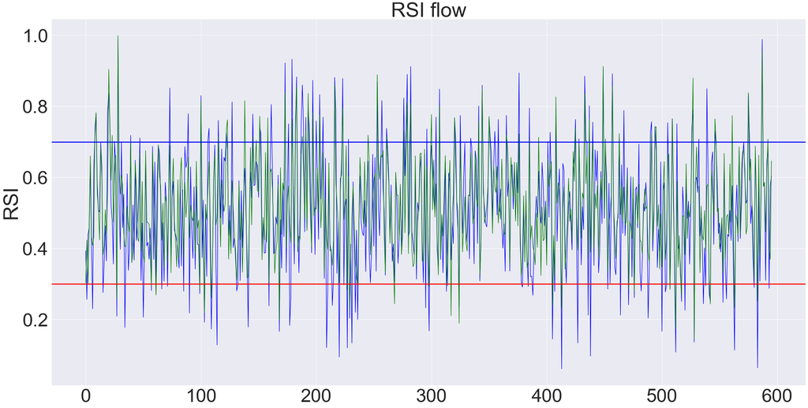

```python
plt.figure(figsize=(40, 20))
sns.set(font_scale = 5)
plt.plot(predicted_table.index, predicted_table['rsi'], color='blue')
plt.plot(predicted_table.index, predicted_table['predicted'], color='green')
plt.axhline(y=0.3, color='red', linewidth=3)
plt.axhline(y=0.7, color='blue', linewidth=3)

plt.title('RSI flow')
plt.ylabel('RSI')
plt.show()
```